# Ejecución presupuestal de la Universidad Nacional Agraria de la Selva en comparación con las universidades públicas del Perú, 2025

Cuaderno del análisis exploratorio de datos

Autores/as

Elida Andrea Campos Flores

Nicole Geraldine Díaz Gumán

Darikson Anyelo Enrique Debarbiere

Fecha de publicación

octubre de 2026

Este documento sigue la lista de verificación del análisis exploratorio de datos del capítulo 4 de *The Art of Data Science* (Peng y Matsui). Cada sección corresponde a uno de sus 9 pasos. Las fuentes de los datos, su preparación y los resultados se describen en el *Informe del análisis exploratorio de datos*.

# 1 Formular la pregunta

Nuestra pregunta principal es:

> **¿Qué tan bien ejecutó la UNAS su presupuesto en 2025 en comparación con las demás universidades públicas, y en qué lo gastó?**

Para responderla la dividimos en preguntas más pequeñas:

1. ¿Qué porcentaje de su presupuesto (PIM) llegó a devengar la UNAS y en qué puesto queda?
2. ¿En qué tipo de gasto se va el presupuesto de la UNAS y en qué se diferencia del resto?
3. ¿Cómo avanzó el gasto mes a mes?
4. ¿Las universidades con más presupuesto ejecutan menos?

Antes de mirar los datos, **esperábamos** que la UNAS estuviera cerca del promedio, que diciembre fuera el mes con más gasto y que las universidades más grandes ejecutaran un porcentaje menor, porque manejan más proyectos.

# 2 Leer los datos

Usamos la base preparada con el script `03_Scripts/02_preparar_presupuesto.R`, que viene del archivo `2025-Gasto-Mensual.csv` del MEF.

**Ver código**

```r
gasto <- readRDS("../04_Datos/procesado/presupuesto_universidades_2025.rds")
```

# 3 Revisar la estructura

**Ver código**

```r
dim(gasto)
```

```
[1] 364434     66
```

**Ver código**

```r
gasto %>%
  select(pliego, universidad, mes_eje, tipo_fila, generica_nombre,
         fuente_financiamiento_nombre, tipo_act_proy_nombre,
         monto_pia, monto_pim, monto_devengado) %>%
  glimpse()
```

```
Rows: 364,434
Columns: 10
$ pliego                       <chr> "541", "541", "541", "541", "541", "541",…
$ universidad                  <chr> "Toribio Rodriguez de Mendoza de Amazonas…
$ mes_eje                      <int> 9, 9, 9, 9, 9, 9, 9, 9, 9, 9, 9, 9, 9, 9,…
$ tipo_fila                    <chr> "Ejecución del mes", "Ejecución del mes",…
$ generica_nombre              <chr> "BIENES Y SERVICIOS", "BIENES Y SERVICIOS…
$ fuente_financiamiento_nombre <chr> "DONACIONES Y TRANSFERENCIAS", "RECURSOS …
$ tipo_act_proy_nombre         <chr> "ACTIVIDAD", "ACTIVIDAD", "ACTIVIDAD", "A…
$ monto_pia                    <dbl> 0, 0, 0, 0, 0, 0, 0, 0, 0, 0, 0, 0, 0, 0,…
$ monto_pim                    <dbl> 0, 0, 0, 0, 0, 0, 0, 0, 0, 0, 0, 0, 0, 0,…
$ monto_devengado              <dbl> 1840.00, 0.00, 24095.39, 0.00, 0.00, 0.00…
```

La base tiene 364,434 filas y 66 columnas. Los códigos (pliego, meta, clasificadores) son texto y los seis montos son numéricos. La variable `tipo_fila` separa dos clases de filas:

**Ver código**

```r
count(gasto, tipo_fila)
```

```
# A tibble: 2 × 2
  tipo_fila                n
  <chr>                <int>
1 Ejecución del mes   299635
2 Presupuesto del año  64799
```

Las filas de **presupuesto del año** (mes 0) son las únicas que traen PIA y PIM. Las de **ejecución del mes** (meses 1 a 12) traen certificado, compromiso, devengado y girado.

# 4 Mirar el inicio y el final de los datos

**Ver código**

```r
cols <- c("universidad", "mes_eje", "generica_nombre", "monto_pim", "monto_devengado")
head(gasto[, cols], 5)
```

```
# A tibble: 5 × 5
  universidad                  mes_eje generica_nombre monto_pim monto_devengado
  <chr>                          <int> <chr>               <dbl>           <dbl>
1 Toribio Rodriguez de Mendoz…       9 BIENES Y SERVI…         0           1840
2 Toribio Rodriguez de Mendoz…       9 BIENES Y SERVI…         0              0
3 Toribio Rodriguez de Mendoz…       9 PERSONAL Y OBL…         0          24095.
4 Toribio Rodriguez de Mendoz…       9 BIENES Y SERVI…         0              0
5 Toribio Rodriguez de Mendoz…       9 BIENES Y SERVI…         0              0
```

**Ver código**

```r
tail(gasto[, cols], 5)
```

```
# A tibble: 5 × 5
  universidad                  mes_eje generica_nombre monto_pim monto_devengado
  <chr>                          <int> <chr>               <dbl>           <dbl>
1 Intercultural de la Amazonia       0 BIENES Y SERVI…    118900               0
2 Intercultural de la Amazonia       0 BIENES Y SERVI…      7176               0
3 Intercultural de la Amazonia       0 OTROS GASTOS        20000               0
4 Intercultural de la Amazonia       0 BIENES Y SERVI…       924               0
5 Intercultural de la Amazonia       0 BIENES Y SERVI…     33000               0
```

Al revisar el inicio y el final notamos que el archivo **no sigue un orden útil para nosotros**: empieza con filas de setiembre (mes 9) de una universidad y termina con filas de presupuesto (mes 0) de otra. También se ve que en las filas de ejecución el PIM es 0 y en las de presupuesto el devengado es 0, lo que confirma lo descrito en el paso anterior. Por eso todos los cálculos los hacemos agrupando, nunca tomando filas por su posición.

# 5 Revisar las «n»

**Ver código**

```r
c(universidades = n_distinct(gasto$pliego),
  meses = n_distinct(gasto$mes_eje),
  genericas = n_distinct(gasto$generica_nombre),
  fuentes = n_distinct(gasto$fuente_financiamiento_nombre))
```

```
universidades         meses     genericas       fuentes
           65            13             7             5
```

**Ver código**

```r
# Valores faltantes en los montos
sapply(gasto[, c("monto_pia", "monto_pim", "monto_devengado", "monto_girado")],
       function(x) sum(is.na(x)))
```

```
      monto_pia       monto_pim monto_devengado    monto_girado
              0               0               0               0
```

**Ver código**

```r
# Filas con devengado negativo (anulaciones o correcciones)
sum(gasto$monto_devengado < 0)
```

```
[1] 3630
```

Tenemos 65 universidades y 13 valores de mes (del 0 al 12), sin montos faltantes. Hay filas con devengado negativo: son correcciones de registros anteriores y las conservamos, porque al sumar se compensan con el registro original.

También revisamos que las etapas del gasto respeten su orden lógico (lo girado no puede superar lo devengado, ni lo devengado al PIM):

**Ver código**

```r
etapas <- gasto %>%
  group_by(pliego) %>%
  summarise(pim = sum(monto_pim), dev = sum(monto_devengado), gir = sum(monto_girado))
c(devengado_mayor_que_pim = sum(etapas$dev > etapas$pim + 1),
  girado_mayor_que_devengado = sum(etapas$gir > etapas$dev + 1))
```

```
   devengado_mayor_que_pim girado_mayor_que_devengado
                         0                          1
```

**Ver código**

```r
# ¿Cuál es el caso con girado mayor que devengado?
etapas %>%
  filter(gir > dev + 1) %>%
  mutate(universidad = gasto$universidad[match(pliego, gasto$pliego)], diferencia = gir - dev)
```

```
# A tibble: 1 × 6
  pliego       pim        dev        gir universidad            diferencia
  <chr>      <dbl>      <dbl>      <dbl> <chr>                       <dbl>
1 531    191860567 147250713. 147262800. Jorge Basadre Grohmann     12088.
```

Ninguna universidad devengó más que su PIM. Solo hay **un caso con girado mayor que devengado**: la Universidad Jorge Basadre Grohmann, por unos S/ 12 mil. Al revisar la Consulta Amigable (paso 6) vimos que allí aparece igual, así que es un dato de la fuente y no un error nuestro. Puede deberse a pagos de obligaciones de años anteriores. Como la diferencia es mínima, la dejamos como está.

# 6 Validar con una fuente externa

Comparamos nuestros totales por universidad con la **Consulta Amigable del MEF**, la herramienta oficial de consulta del presupuesto. La descargamos con el script `03_Scripts/03_consultar_consulta_amigable.py` (2025, Gobierno Nacional, sector Educación, por pliego).

**Ver código**

```r
ca <- read.csv("../04_Datos/raw/consulta_amigable_educacion_2025.csv",
               colClasses = c(pliego = "character"), encoding = "UTF-8") %>%
  filter(as.integer(pliego) >= 510) %>%
  mutate(universidad = nombre_corto(pliego_nombre))

comparacion <- ca %>%
  left_join(etapas, by = "pliego") %>%
  mutate(dif_pim = pim.x - pim.y, dif_dev = devengado - dev)

c(universidades_consulta_amigable = nrow(ca),
  coinciden_al_sol = sum(abs(comparacion$dif_pim) <= 1 & abs(comparacion$dif_dev) <= 1, na.rm = TRUE),
  diferencia_menor_a_S300 = sum(abs(comparacion$dif_pim) <= 1 & abs(comparacion$dif_dev) > 1 &
                                  abs(comparacion$dif_dev) < 300, na.rm = TRUE))
```

```
universidades_consulta_amigable                coinciden_al_sol
                             65                              63
        diferencia_menor_a_S300
                              2
```

**Ver código**

```r
comparacion %>%
  filter(is.na(pim.y) | abs(dif_pim) > 1 | abs(dif_dev) > 300) %>%
  transmute(pliego, pliego_nombre, pim_consulta = pim.x, pim_nuestro = pim.y, dif_pim)
```

```
[1] pliego        pliego_nombre pim_consulta  pim_nuestro   dif_pim
<0 rows> (o 0- extensión row.names)
```

La validación muestra que nuestra base reproduce las cifras oficiales:

- **La UNAS coincide exactamente**: PIM de S/ 102,669,837 y devengado de S/ 101,713,327 en ambas fuentes.
- **63 universidades coinciden al sol** y 2 difieren en menos de S/ 300, por redondeo.
- La tabla de diferencias mayores está vacía: no hay universidades con montos distintos.

Por eso usamos la Consulta Amigable para comparar el avance de las 65 universidades y nuestra base para el detalle por mes, tipo de gasto y fuente.

# 7 Hacer gráficos

## 7.1 ¿Cuánto ejecutó cada universidad?

**Ver código**

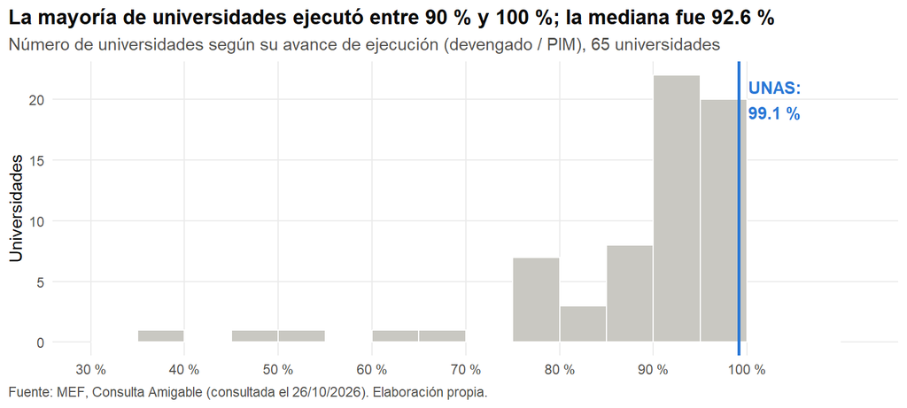

Figura 1

```r
avance_conjunto <- 100 * sum(ca$devengado) / sum(ca$pim)
unas <- filter(ca, pliego == "526")

ggplot(ca, aes(x = avance_pct)) +
  geom_histogram(binwidth = 5, boundary = 0, fill = gris, color = "white") +
  geom_vline(xintercept = unas$avance_pct, color = azul, linewidth = 1) +
  annotate("text", x = unas$avance_pct + 1, y = Inf, vjust = 1.5, hjust = 0, color = azul, fontface = "bold",
           label = sprintf("UNAS:\n%.1f %%", unas$avance_pct)) +
  scale_x_continuous(breaks = seq(30, 100, 10), labels = function(x) paste0(x, " %"),
                     limits = c(30, 112)) +
  labs(title = sprintf("La mayoría de universidades ejecutó entre 90 %% y 100 %%; la mediana fue %.1f %%",
                       median(ca$avance_pct)),
       subtitle = "Número de universidades según su avance de ejecución (devengado / PIM), 65 universidades",
       x = NULL, y = "Universidades", caption = fuente_ca) +
  tema
```

La distribución está **cargada hacia la derecha**: la mayoría ejecuta más del 90 %, y unas pocas universidades se quedan muy atrás, por debajo del 70 %. La UNAS está en el grupo más alto.

**Ver código**

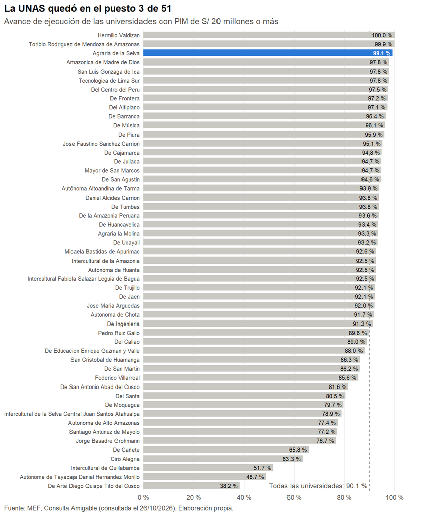

Figura 2

```r
ranking <- ca %>%
  filter(pim >= 20e6) %>%
  arrange(desc(devengado / pim)) %>%
  mutate(puesto = row_number(), es_unas = pliego == "526",
         universidad = reorder(universidad, devengado / pim))
puesto_unas <- ranking$puesto[ranking$es_unas]

# La línea del promedio va detrás de las barras para no tapar los porcentajes
ggplot(ranking, aes(x = avance_pct, y = universidad, fill = es_unas)) +
  geom_vline(xintercept = avance_conjunto, linetype = "dashed", color = texto2) +
  geom_col(width = 0.75) +
  annotate("text", x = avance_conjunto - 1, y = 1, hjust = 1, size = 3.2, color = texto2,
           label = sprintf("Todas las universidades: %.1f %%", avance_conjunto)) +
  geom_text(aes(label = sprintf("%.1f %%", avance_pct), color = es_unas,
                fontface = if_else(es_unas, "bold", "plain")),
            hjust = 1.1, size = 2.6) +
  scale_fill_manual(values = c(`TRUE` = azul, `FALSE` = gris), guide = "none") +
  scale_color_manual(values = c(`TRUE` = "white", `FALSE` = texto), guide = "none") +
  scale_x_continuous(limits = c(0, 114), breaks = seq(0, 100, 20),
                     labels = function(x) paste0(x, " %"), expand = c(0, 0)) +
  labs(title = sprintf("La UNAS quedó en el puesto %d de %d", puesto_unas, nrow(ranking)),
       subtitle = "Avance de ejecución de las universidades con PIM de S/ 20 millones o más",
       x = NULL, y = NULL, caption = fuente_ca) +
  tema +
  theme(panel.grid.major.y = element_blank(), axis.text.y = element_text(size = 7.5))
```

## 7.2 ¿En qué gasta la UNAS?

**Ver código**

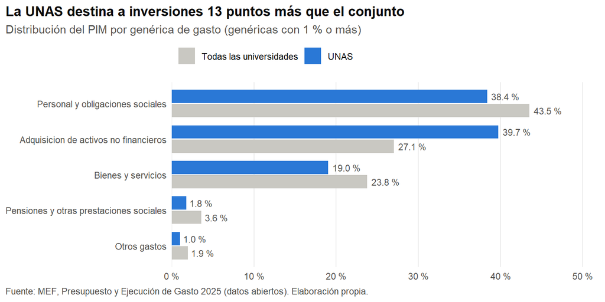

Figura 3

```r
composicion <- gasto %>%
  filter(mes_eje == 0) %>%
  mutate(grupo = if_else(es_unas, "UNAS", "Todas las universidades")) %>%
  bind_rows(filter(., grupo == "UNAS") %>% mutate(grupo = "Todas las universidades")) %>%
  group_by(grupo, generica_nombre) %>%
  summarise(pim = sum(monto_pim), .groups = "drop_last") %>%
  mutate(porcentaje = 100 * pim / sum(pim)) %>%
  group_by(generica_nombre) %>%
  filter(any(grupo == "Todas las universidades" & porcentaje >= 1)) %>%
  ungroup() %>%
  mutate(generica = oracion(generica_nombre),
         generica = reorder(generica, porcentaje),
         grupo = factor(grupo, levels = c("Todas las universidades", "UNAS")))

ggplot(composicion, aes(x = porcentaje, y = generica, fill = grupo)) +
  geom_col(position = position_dodge(width = 0.8), width = 0.75) +
  geom_text(aes(label = sprintf("%.1f %%", porcentaje)), position = position_dodge(width = 0.8),
            hjust = -0.15, size = 3, color = texto2) +
  scale_fill_manual(values = c(UNAS = azul, `Todas las universidades` = gris), name = NULL) +
  scale_x_continuous(limits = c(0, 52), labels = function(x) paste0(x, " %"), expand = c(0, 0)) +
  labs(title = "La UNAS destina a inversiones 13 puntos más que el conjunto",
       subtitle = "Distribución del PIM por genérica de gasto (genéricas con 1 % o más)",
       x = NULL, y = NULL, caption = fuente_mef) +
  tema +
  theme(legend.position = "top", legend.justification = "left", panel.grid.major.y = element_blank())
```

Las universidades en conjunto gastan sobre todo en **personal** (44 % del PIM). La UNAS, en cambio, reparte su presupuesto casi por igual entre personal (38 %) e **inversiones** (40 %, «adquisición de activos no financieros»). Esto llama la atención porque las inversiones suelen ser lo más difícil de ejecutar, como vemos en el paso 8.

## 7.3 ¿Cómo avanzó el gasto en el año?

**Ver código**

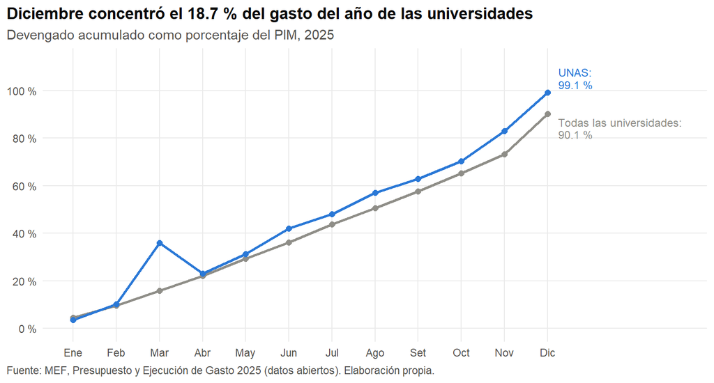

Figura 4

```r
mensual <- bind_rows(
  gasto %>% filter(es_unas) %>% mutate(grupo = "UNAS"),
  gasto %>% mutate(grupo = "Todas las universidades")
) %>%
  group_by(grupo) %>%
  mutate(pim = sum(monto_pim)) %>%
  filter(mes_eje > 0) %>%
  group_by(grupo, mes_eje, pim) %>%
  summarise(devengado = sum(monto_devengado), .groups = "drop") %>%
  arrange(grupo, mes_eje) %>%
  group_by(grupo) %>%
  mutate(avance_acum = 100 * cumsum(devengado) / pim,
         parte_del_anio = 100 * devengado / sum(devengado)) %>%
  ungroup()

dic <- filter(mensual, mes_eje == 12) %>%
  mutate(y_etiqueta = avance_acum + if_else(grupo == "UNAS", 6, -6))
meses <- c("Ene", "Feb", "Mar", "Abr", "May", "Jun", "Jul", "Ago", "Set", "Oct", "Nov", "Dic")

ggplot(mensual, aes(x = mes_eje, y = avance_acum, color = grupo)) +
  geom_line(linewidth = 1) +
  geom_point(size = 2) +
  geom_text(data = dic, aes(y = y_etiqueta, label = sprintf("%s:\n%.1f %%", grupo, avance_acum)),
            hjust = 0, nudge_x = 0.25, size = 3.2, lineheight = 0.9, show.legend = FALSE) +
  scale_color_manual(values = c(UNAS = azul, `Todas las universidades` = gris_linea), guide = "none") +
  scale_x_continuous(breaks = 1:12, labels = meses, limits = c(1, 15)) +
  scale_y_continuous(limits = c(0, 112), breaks = seq(0, 100, 20), labels = function(x) paste0(x, " %")) +
  labs(title = sprintf("Diciembre concentró el %.1f %% del gasto del año de las universidades",
                       dic$parte_del_anio[dic$grupo == "Todas las universidades"]),
       subtitle = "Devengado acumulado como porcentaje del PIM, 2025",
       x = NULL, y = NULL, caption = fuente_mef) +
  tema
```

Se confirma lo que esperábamos: el gasto se acelera al final del año y **diciembre es el mes con más devengado**. La UNAS va por encima del conjunto casi todo el año, salvo por un salto en marzo y una caída en abril que revisamos en el paso 9.

# 8 Probar primero la solución fácil

La explicación más simple que se nos ocurrió es que **las universidades con más presupuesto ejecutan menos**, porque tienen más proyectos y más trámites. La probamos con las 65 universidades de la Consulta Amigable:

**Ver código**

```r
# Se usa el avance sin redondear (devengado / PIM) para que coincida con el informe
prueba <- cor.test(log10(ca$pim), 100 * ca$devengado / ca$pim, method = "spearman", exact = FALSE)
prueba
```

```
    Spearman's rank correlation rho

data:  log10(ca$pim) and 100 * ca$devengado/ca$pim
S = 46610, p-value = 0.8832
alternative hypothesis: true rho is not equal to 0
sample estimates:
        rho
-0.01857517
```

**Ver código**

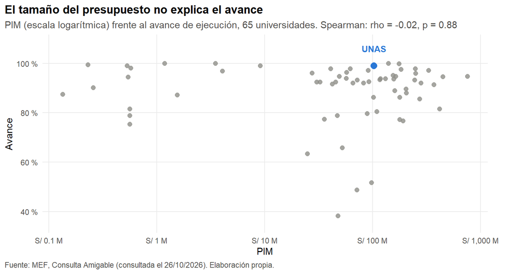

Figura 5

```r
ggplot(ca, aes(x = pim / 1e6, y = avance_pct)) +
  geom_point(data = filter(ca, pliego != "526"), color = gris_linea, size = 2.2, alpha = 0.8) +
  geom_point(data = unas, color = azul, size = 3.2) +
  annotate("text", x = unas$pim / 1e6, y = 106, label = "UNAS",
           color = azul, fontface = "bold", size = 3.4) +
  scale_x_log10(breaks = c(0.1, 1, 10, 100, 1000), labels = c("S/ 0.1 M", "S/ 1 M", "S/ 10 M", "S/ 100 M", "S/ 1,000 M")) +
  scale_y_continuous(limits = c(35, 108), breaks = seq(40, 100, 20), labels = function(x) paste0(x, " %")) +
  labs(title = "El tamaño del presupuesto no explica el avance",
       subtitle = sprintf("PIM (escala logarítmica) frente al avance de ejecución, 65 universidades. Spearman: rho = %.2f, p = %.2f",
                          prueba$estimate, prueba$p.value),
       x = "PIM", y = "Avance", caption = fuente_ca) +
  tema +
  theme(plot.margin = margin(5.5, 25, 5.5, 5.5))
```

La correlación de Spearman es prácticamente cero (rho = -0.02, p = 0.88): **no hay relación entre el tamaño del presupuesto y el avance**. La explicación fácil queda descartada.

Probamos entonces la segunda idea: ¿los **proyectos de inversión** se ejecutan peor que las actividades del día a día?

**Ver código**

```r
tipo <- gasto %>%
  group_by(es_unas, tipo_act_proy_nombre) %>%
  summarise(pim = sum(monto_pim), dev = sum(monto_devengado), .groups = "drop") %>%
  bind_rows(gasto %>% group_by(tipo_act_proy_nombre) %>%
              summarise(pim = sum(monto_pim), dev = sum(monto_devengado)) %>%
              mutate(es_unas = NA)) %>%
  mutate(grupo = case_when(is.na(es_unas) ~ "Todas las universidades", es_unas ~ "UNAS")) %>%
  filter(!is.na(grupo)) %>%
  group_by(grupo) %>%
  mutate(parte_del_pim = round(100 * pim / sum(pim), 1), avance = round(100 * dev / pim, 1)) %>%
  ungroup() %>%
  select(grupo, tipo = tipo_act_proy_nombre, pim_millones = pim, parte_del_pim, avance) %>%
  mutate(pim_millones = round(pim_millones / 1e6, 1))
knitr::kable(tipo, col.names = c("Grupo", "Tipo", "PIM (S/ millones)", "% del PIM", "Avance (%)"))
```

| Grupo | Tipo | PIM (S/ millones) | % del PIM | Avance (%) |
| --- | --- | --- | --- | --- |
| UNAS | ACTIVIDAD | 64.3 | 62.7 | 98.9 |
| UNAS | PROYECTO | 38.3 | 37.3 | 99.4 |
| Todas las universidades | ACTIVIDAD | 6073.2 | 78.5 | 93.2 |
| Todas las universidades | PROYECTO | 1660.8 | 21.5 | 78.6 |

Aquí sí hay una diferencia clara: en el conjunto, los **proyectos se ejecutan bastante menos que las actividades** (alrededor de 79 % frente a 93 %). Lo destacable es que la UNAS tiene una parte mucho mayor de su presupuesto en proyectos y aun así los ejecutó casi por completo. Esto explica buena parte de su buen resultado: no tiene un «freno» en sus inversiones como muchas otras universidades.

# 9 Preguntas de seguimiento

## 9.1 ¿Qué pasó en la UNAS en marzo y abril?

En el gráfico mensual la UNAS sube a 36 % en marzo y baja a 23 % en abril, algo imposible si solo se sumara gasto. Lo revisamos por genérica:

**Ver código**

```
# A tibble: 16 × 3
   mes_eje especifica_det_nombre                              devengado_millones
     <int> <chr>                                                           <dbl>
 1       3 CONTRATO ADMINISTRATIVO DE SERVICIOS - TRANSITORIO               0.11
 2       3 CONTRATO ADMINISTRATIVO DE SERVICIOS - INDETERMIN…               0.12
 3       3 CONTRIBUCIONES A ESSALUD DE REGÍMENES ESPECIALES …               0.13
 4       3 OTRAS RETRIBUCIONES Y COMPLEMENTOS                               0.25
 5       3 ASIGNACION A FONDOS PARA PERSONAL                                0.31
 6       3 PERSONAL ADMINISTRATIVO NOMBRADO (REGIMEN PUBLICO)               0.52
 7       3 FUNCIONARIOS DE ALTA DIRECCIÓN DE LAS ENTIDADES                  0.64
 8       3 PERSONAL CONTRATADO                                              2.73
 9       3 PERSONAL NOMBRADO                                               14.4
10       4 PERSONAL NOMBRADO                                              -11.5
11       4 PERSONAL CONTRATADO                                             -2.68
12       4 FUNCIONARIOS DE ALTA DIRECCIÓN DE LAS ENTIDADES                 -0.5
13       4 CONTRATO ADMINISTRATIVO DE SERVICIOS - INDETERMIN…               0.12
14       4 CONTRIBUCIONES A ESSALUD DE REGÍMENES ESPECIALES …               0.14
15       4 CONTRATO ADMINISTRATIVO DE SERVICIOS - TRANSITORIO               0.15
16       4 ASIGNACION A FONDOS PARA PERSONAL                                0.31
```

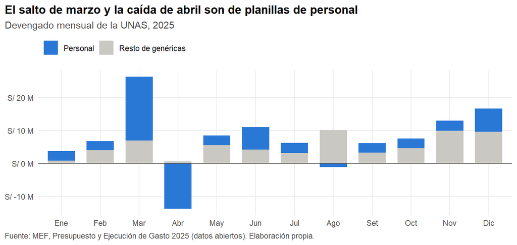

Figura 6

```r
unas_mes <- gasto %>%
  filter(es_unas, mes_eje > 0) %>%
  mutate(rubro = if_else(generica_nombre == "PERSONAL Y OBLIGACIONES SOCIALES",
                         "Personal", "Resto de genéricas")) %>%
  group_by(mes_eje, rubro) %>%
  summarise(devengado = sum(monto_devengado) / 1e6, .groups = "drop")

ggplot(unas_mes, aes(x = factor(mes_eje, labels = meses), y = devengado, fill = rubro)) +
  geom_col(width = 0.7) +
  geom_hline(yintercept = 0, color = texto2) +
  scale_fill_manual(values = c(Personal = azul, `Resto de genéricas` = gris), name = NULL) +
  scale_y_continuous(labels = function(x) paste0("S/ ", x, " M")) +
  labs(title = "El salto de marzo y la caída de abril son de planillas de personal",
       subtitle = "Devengado mensual de la UNAS, 2025",
       x = NULL, y = NULL, caption = fuente_mef) +
  tema +
  theme(legend.position = "top", legend.justification = "left")

gasto %>%
  filter(es_unas, mes_eje %in% 3:4, generica_nombre == "PERSONAL Y OBLIGACIONES SOCIALES") %>%
  group_by(mes_eje, especifica_det_nombre) %>%
  summarise(devengado_millones = round(sum(monto_devengado) / 1e6, 2), .groups = "drop") %>%
  filter(abs(devengado_millones) >= 0.1) %>%
  arrange(mes_eje, devengado_millones)
```

Todo el movimiento está en **personal**: en marzo se devengaron unos S/ 19 millones en planillas (sobre todo personal docente nombrado y contratado) y en abril se registraron S/ 13.7 millones en negativo en esas mismas partidas. Nuestra interpretación es que en marzo se registró por adelantado el devengado de varios meses de planilla y en abril se corrigió. Es un **ajuste contable**, no dinero que se gastó y se devolvió. Para el análisis anual no cambia nada, porque los montos se compensan.

## 9.2 Otras preguntas que quedan abiertas

- ¿Por qué las universidades de Arte Diego Quispe Tito del Cusco, Tayacaja y Quillabamba ejecutaron menos del 55 %? Sería útil revisar qué proyectos no avanzaron.
- ¿La UNAS mantiene este nivel otros años? Con el mismo script se puede descargar 2024 y comparar.
- ¿En qué proyectos específicos invirtió la UNAS sus S/ 38 millones? La base tiene el nombre de cada proyecto.

# 10 Conclusiones

1. **La UNAS ejecutó el 99.1 % de su presupuesto en 2025** (S/ 101.7 millones de S/ 102.7 millones), muy por encima del conjunto de universidades (90.1 %). Quedó en el **puesto 3 de 51** universidades con PIM de S/ 20 millones o más.
2. **Su perfil de gasto es distinto**: destina el 40 % del presupuesto a inversiones, frente al 27 % del conjunto, y aun así ejecutó sus proyectos al 99 %.
3. **El tamaño del presupuesto no explica la ejecución**; lo que sí marca diferencia es la ejecución de proyectos, que en el conjunto es mucho menor que la de las actividades.
4. **Diciembre concentra casi la quinta parte del gasto anual**, como esperábamos.
5. **Las cifras son confiables**: coinciden con la Consulta Amigable del MEF en las 65 universidades (63 al sol y 2 con diferencias de redondeo).

**Limitaciones:** el avance mide cuánto se gastó, no si se gastó bien; y analizamos un solo año.